# Construindo uma estratégia de negócio

## Conceitos

- **fast signal**: é mais proximamente associado às variações diários de preços e refletem mudanças no curto prazo
- **slow signal**: é menos associado às variações diárias de preço do que o *fast signal* e reflete as mudanças de preço no longo prazo.

Além disso, outros termos utilizados no campo da economia e do mercado financeiro serão comuns aqui:

- **share**: são ações, títulos
- **long**: é o ato de comprar ações com a expectativa de que o preço subirá (long position), em geral sem a expectativa de manter as ações por muito tempo, mas sim de vendê-las quando oportuno para obter lucros pela alta esperada.

## Carregar bibliotecas

```python
import pandas as pd
import matplotlib.pyplot as plt
from pylab import *
```

## Importar os dados

```python
ms = pd.read_csv('../data/microsoft.csv', parse_dates = ['Date'], index_col = ['Date'])
ms.head()
```

| Date | Open | High | Low | Close | Adj Close | Volume |
| --- | --- | --- | --- | --- | --- | --- |
| 2014-12-31 | 46.730000 | 47.439999 | 46.450001 | 46.450001 | 42.848763 | 21552500 |
| 2015-01-02 | 46.660000 | 47.419998 | 46.540001 | 46.759998 | 43.134731 | 27913900 |
| 2015-01-05 | 46.369999 | 46.730000 | 46.250000 | 46.330002 | 42.738068 | 39673900 |
| 2015-01-06 | 46.380001 | 46.750000 | 45.540001 | 45.650002 | 42.110783 | 36447900 |
| 2015-01-07 | 45.980000 | 46.459999 | 45.490002 | 46.230000 | 42.645817 | 29114100 |

## A estratégia

Alguns analistas financeiros entendem que *fast signal* > *slow signal* é um indicativo de que as ações deverão subir nos próximos dias do período.

Utilizaremos este entendimento para definir uma estratégia de compra e venda de ações da Microsoft:

> Quando `media10` > `media50` a ação é comprar e manter uma cota das ações.

### Calcular médias móveis

```python
ms['media10'] = ms['Close'].rolling(10).mean()
ms['media50'] = ms['Close'].rolling(50).mean()
ms.loc['2015-01-13':'2015-01-20']
```

| Date | Open | High | Low | Close | Adj Close | Volume | media10 | media50 |
| --- | --- | --- | --- | --- | --- | --- | --- | --- |
| 2015-01-13 | 46.970001 | 47.910000 | 46.060001 | 46.360001 | 42.765747 | 35270600 | NaN | NaN |
| 2015-01-14 | 45.959999 | 46.240002 | 45.619999 | 45.959999 | 42.396751 | 29719600 | 46.512 | NaN |
| 2015-01-15 | 46.220001 | 46.380001 | 45.410000 | 45.480000 | 41.953960 | 32750800 | 46.415 | NaN |
| 2015-01-16 | 45.310001 | 46.279999 | 45.169998 | 46.240002 | 42.655041 | 35695300 | 46.363 | NaN |
| 2015-01-20 | 46.299999 | 46.650002 | 45.570000 | 46.389999 | 42.793415 | 36041400 | 46.369 | NaN |

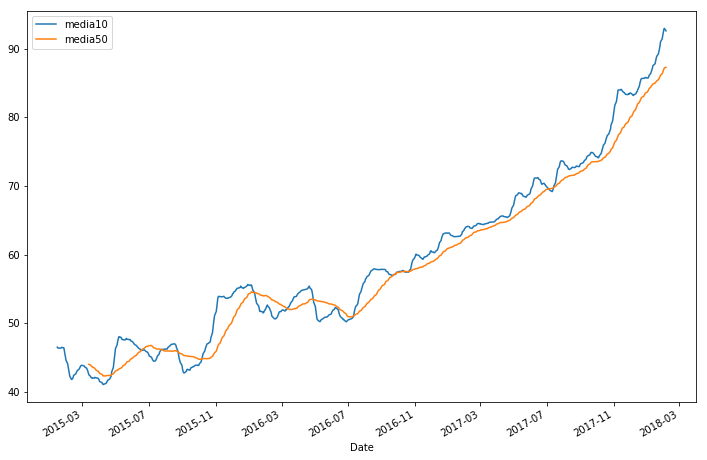

```python
ms[['media10', 'media50']].plot(figsize = (12, 8));
```

Conforme a estratégia, os dias em que a linha azul está acima da linha laranja são os dias em que serão compradas e mantidas cotas das ações da Microsoft.

Criarei agora uma variável informando qual ação a ser tomada naquele dia. A chamarei de "`share`".

```python
ms['share'] = [1 if ms.loc[i, 'media10'] > ms.loc[i, 'media50'] else 0 for i in ms.index]
ms.head()
```

| Date | Open | High | Low | Close | Adj Close | Volume | media10 | media50 | share |
| --- | --- | --- | --- | --- | --- | --- | --- | --- | --- |
| 2014-12-31 | 46.730000 | 47.439999 | 46.450001 | 46.450001 | 42.848763 | 21552500 | NaN | NaN | 0 |
| 2015-01-02 | 46.660000 | 47.419998 | 46.540001 | 46.759998 | 43.134731 | 27913900 | NaN | NaN | 0 |
| 2015-01-05 | 46.369999 | 46.730000 | 46.250000 | 46.330002 | 42.738068 | 39673900 | NaN | NaN | 0 |
| 2015-01-06 | 46.380001 | 46.750000 | 45.540001 | 45.650002 | 42.110783 | 36447900 | NaN | NaN | 0 |
| 2015-01-07 | 45.980000 | 46.459999 | 45.490002 | 46.230000 | 42.645817 | 29114100 | NaN | NaN | 0 |

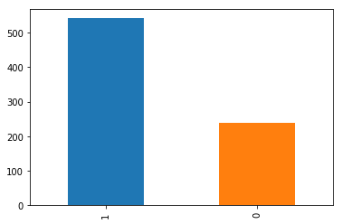

```python
ms['share'].value_counts().plot('bar');
```

Por hora já sei que nesse período eu teria mais dias de compra das ações do que de venda.

Mas seguindo, agora criarei a variável 'lucro_diario'.

```python
ms['close_amanha'] = ms['Close'].shift(-1)
ms['lucro_diario'] = [ms.loc[i, 'close_amanha'] - ms.loc[i, 'Close']
                      if ms.loc[i, 'share'] == 1
                      else 0 for i in ms.index]
ms.head()
```

| Date | Open | High | Low | Close | Adj Close | Volume | media10 | media50 | share | close_amanha | lucro_diario |
| --- | --- | --- | --- | --- | --- | --- | --- | --- | --- | --- | --- |
| 2014-12-31 | 46.730000 | 47.439999 | 46.450001 | 46.450001 | 42.848763 | 21552500 | NaN | NaN | 0 | 46.759998 | 0.0 |
| 2015-01-02 | 46.660000 | 47.419998 | 46.540001 | 46.759998 | 43.134731 | 27913900 | NaN | NaN | 0 | 46.330002 | 0.0 |
| 2015-01-05 | 46.369999 | 46.730000 | 46.250000 | 46.330002 | 42.738068 | 39673900 | NaN | NaN | 0 | 45.650002 | 0.0 |
| 2015-01-06 | 46.380001 | 46.750000 | 45.540001 | 45.650002 | 42.110783 | 36447900 | NaN | NaN | 0 | 46.230000 | 0.0 |
| 2015-01-07 | 45.980000 | 46.459999 | 45.490002 | 46.230000 | 42.645817 | 29114100 | NaN | NaN | 0 | 47.590000 | 0.0 |

A variável indica zero para os dias em que não foram feitas transações. E indica o lucro para os dias em que houve. O lucro pode ser positivo ou negativo.

Vou plotar a variavel `lucro_diario` para ver o desempenho líquido da estratégia.

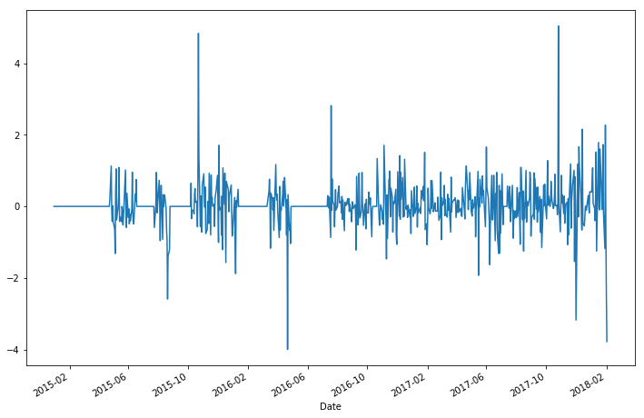

```python
ms['lucro_diario'].plot(figsize = (12,8));
```

A análise é simples, nos dias acima de 0 houve lucro e nos dias abaixo de zero perde-se dinheiro. Mas para compreender o desempenho é preciso resumir esse resultado.

```python
ms['fortuna'] = ms['lucro_diario'].cumsum()
ms.tail()
```

| Date | Open | High | Low | Close | Adj Close | Volume | media10 | media50 | share | close_amanha | lucro_diario | fortuna |
| --- | --- | --- | --- | --- | --- | --- | --- | --- | --- | --- | --- | --- |
| 2018-01-30 | 93.300003 | 93.660004 | 92.099998 | 92.739998 | 92.306389 | 38635100 | 91.862 | 86.5244 | 1 | 95.010002 | 2.270004 | 30.540009 |
| 2018-01-31 | 93.750000 | 95.400002 | 93.510002 | 95.010002 | 94.565781 | 48756300 | 92.349 | 86.7606 | 1 | 94.260002 | -0.750000 | 29.790009 |
| 2018-02-01 | 94.790001 | 96.070000 | 93.580002 | 94.260002 | 93.819290 | 47227900 | 92.765 | 86.9978 | 1 | 91.779999 | -2.480003 | 27.310006 |
| 2018-02-02 | 93.639999 | 93.970001 | 91.500000 | 91.779999 | 91.350883 | 47867800 | 92.943 | 87.1828 | 1 | 88.000000 | -3.779999 | 23.530007 |
| 2018-02-05 | 90.559998 | 93.239998 | 88.000000 | 88.000000 | 87.588554 | 51031500 | 92.582 | 87.2684 | 1 | NaN | NaN | NaN |

A função `.cumsum()` procede com a soma cumulativa, então o último valor da variável corresponde ao lucro acumulado com esta estratégia de compra das ações da Microsoft.

```python
ms['fortuna'].iloc[-2]
```

```
23.53000699999999
```

Como o resultado foi de lucro positivo, o gasto foi apenas o investimento inicial na compra da ação no primeiro dia de *long action*.

```python
ms.loc[ms['share'] == 1, 'Close'].iloc[0]
```

```
47.869999
```

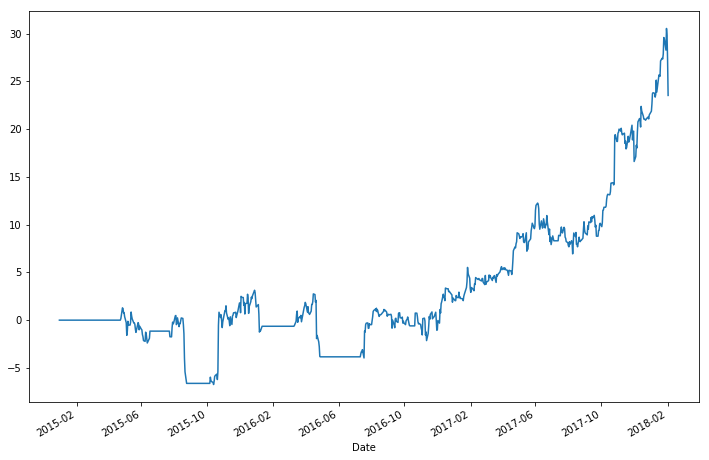

```python
ms['fortuna'].plot(figsize = (12, 8));
```

O gráfico de evolução da fortuna indica que nos primeiros dois anos, quase, as ações não deram muito lucro, mas a partir de 2017 ela começa a dar lucro, de modo que foram ganhos 24 dólares no período, transacionado uma cota de açao a cada negócio.

## Conclusões

Esta é uma estratégia simplista e como intuito de servir de tutorial de referência para uso de Python para análise de dados financeiros.

Para aplicação no mundo real, seria preciso responder muitas perguntas que ficam em aberto, como:

- É possível encontrar um melhor *signal* para negociar?
- Como avaliar a performance da estratégia corretamente?

```python
ms.columns
```

```
Index(['Open', 'High', 'Low', 'Close', 'Adj Close', 'Volume', 'media10',
       'media50', 'share', 'close_amanha', 'lucro_diario', 'fortuna'],
      dtype='object')
```